# Theory of Branching Processes

Jackson Van Vooren

March 1, 2024

## Prerequisites

You should be familiar with discrete time Markov chains on a countably infinite state space. It may be helpful to understand some basic properties of generating functions, though definitions and examples will be provided.

## Introduction

A branching process, also known as a Galton-Watson process, is a model for growth of a population over time. It is a branching stochastic process that arose out of Francis Galton’s statistical research on the extinction of a family’s last name.

Galton-Watson processes assume no distinction in sex (just as family names are passed patrilineally). As a result, this model is widely used to examine phenomena such as the transmission of the Y chromosome (paternal) or mitochondria (maternal). Such branching processes are also used to model the population growth of a bacterium that reproduces asexually.

## Key definitions in a branching process

### The offspring distribution

The offspring distribution, $\{p_k\}$, is the set of probabilities that an individual will have $k$ offspring. It is given by,
$$\{p_k\}_{k=0,1,2,\dots} \quad \text{with } \; p_k
\geq 0
\quad \text{and } \; \sum_{k=0}^{\infty} p_k =
1.$$
Define $\mu$, the mean of the offspring distribution, as
$$\mu =
\mathbb{E}[Z_n] = \sum_{k=1}^{\infty} k p_k$$
Let $Z_n$ be the size of a population at time (or generation) $n$. We assume each individual reproduces **independently** of each other according to $\{p_k\}$. Formally, let $\eta_j$ be the number of offspring individual $j$ has, where $j$ is a member of generation $n$ and its offspring are a part of $n+1$. Then, the number of individuals in the population at generation $n+1$ is,
$$Z_{n+1} = \sum_{j=1}^{Z_n} \eta_j
\quad\quad \text{with } \;
\mathbb{P}[\eta_j = k | Z_n = \ell]
= p_k.$$
That is, the number of individuals of the next generation is the sum of the number of offspring of all individuals in the prior generation. This model, then, assumes that the organism dies after giving birth.

By requiring the conditional independence of the $\eta_j$’s given $Z_n$, $\{Z_n\}$ forms a Markov chain. The number of individuals of generation $n+1$ only depends on how many individuals there are currently at time $n$.

### Extinction probability

Broadly, we are interested in determining how likely a given population is to go extinct. Define the extinction probability, $P_e$, as,
$$P_e
= \mathbb{P}[\text{ there exists } n \in \mathbb{N} \text{ such that }
Z_n = 0 \;|\; Z_0 = 1]$$
If we start with one individual, we are interested in asking, will the population go extinct? If so, can we infer how long extinction will take?

## Simulating a branching process

Before proving results about Galton-Watson processes, we can simulate these Markov chains, $\{Z_n\}$, to get a general idea of answers to these questions. $\{Z_n\}$ is essentially a tree, where each $i$ is a level with $Z_i$ nodes.

Let’s assume we start with one individual, $Z_0 = 1$. And suppose each individual reproduces with offspring distribution $\{p_k\} \sim \text{Poisson}(\lambda)$.

```r
simulate_bp <- function(num_generations, lambda) {
  total_individuals <- numeric(num_generations)
  total_individuals[1] <- 1             # 1 individual in the first gen

  for (i in 2:num_generations) {
    offspring <- 0

    for (j in 1:total_individuals[i-1]) {
      offspring <- offspring + rpois(1, lambda)
    }
    if (offspring == 0) {
      total_individuals[i] <- 0
      return(total_individuals[1:i])    # Early return if extinct
    }
    total_individuals[i] <- offspring
  }
  return(total_individuals)
}
```

#### $\lambda = 1$

The below code simulates 5 trials of 10 generations of a branching process with offspring distribution Poission($1$). With $\lambda = 1$, some of the branching processes go extinct, while others survive through the ten generations. Note that $\mu = \mathbb{E}[\{p_k\}] = \lambda = 1$.

```r
num_trials <- 5
num_generations <- 10
lambda <- 1

run_trials <- function(num_trials, num_generations, lambda){
  for (trial in 1:num_trials){
    result <- simulate_bp(num_generations, lambda)
    print(result)
  }
}

trials <- run_trials(num_trials, num_generations, lambda)
```

```
 [1] 1 1 2 4 2 5 2 2 1 3
[1] 1 1 0
[1] 1 3 3 2 3 1 1 0
 [1] 1 2 3 3 5 1 3 2 2 1
[1] 1 1 0
```

#### $\lambda = 4$

Suppose we take $\lambda = 4$. None of the branching processes go extinct. In fact, with a Poisson offspring distribution, we see very quick exponential growth in the number of total individuals of the population. Intuitively, since the mean of a Poisson distribution is $\lambda = 4$, each individual has $4$ offspring on average.

```r
lambda <- 4
trials <- run_trials(num_trials, num_generations, lambda)
```

```
 [1]      1      6     35    134    584   2377   9501  37821 151038 604892
 [1]      1      2     10     42    169    694   2863  11557  46210 185426
 [1]      1      3      8     32    122    485   1955   7717  30876 123140
 [1]      1      6     18     56    226    904   3565  14376  57384 229545
 [1]      1      6     33    122    477   1906   7647  30661 123204 493280
```

#### $\lambda = 0.5$

If we take $\lambda = 0.5$, you should be able to guess what is going to happen. Since the mean number of offspring per individual is $\mu = 0.5 < 1$, the population cannot be replaced and it goes extinct very quickly.

```r
lambda <- 0.5
trials <- run_trials(num_trials, num_generations, lambda)
```

```
[1] 1 0
[1] 1 1 0
[1] 1 0
[1] 1 1 0
[1] 1 2 2 2 3 0
```

##### Theorem. If $\mu < 1$, then $P_e = 1$.

**Proof.** Assume $Z_0 = 1$ and $\mu < 1$. Then, $\mathbb{E}[Z_n] = \mu^n \to 0$.

This equality follows because the average number of offspring of each individual is independent. In generation 0, there is 1 individual. In generation 1, we expect $\mu$ individuals. In the next generation, each of the $\mu$ individuals has $\mu$ offspring, so $\mathbb{E}[Z_2] = \mu^2$, and so on.

Also, $\mathbb{P}[Z_n \neq 0] = \mathbb{P}[Z_n \geq 1] \leq \mathbb{E}[Z_n] \to 0$. Thus, $\mathbb{P}[Z_n = 0] \to 1$ as $n \to \infty$, as needed.

We call a branching process **subcritical** when $\mu < 1$. To understand the behavior of a **critical** ($\mu=1$) or **supercritical** ($\mu > 1$) branching process, we must discuss probability generating functions.

## Probability generating functions

For a random variable $X$, the probability generating function for $X$, which I will denote $\phi$, with $s \in [0, \infty)$, is
$$\phi(s) =
\mathbb{E}[s^X] = \sum_{k=0}^{\infty}s^k \mathbb{P}[X=k].$$
With a branching process, the probability that $Z_n = k$ is exactly $p_k$, so
$$\phi(s) = \sum_{k=0}^{\infty}s^k p_k.$$
is the generating function.

Observe that $\phi(0) = p_0$ and $\phi(1) = \sum_{k=0}^{\infty} p_k = 1$.

### Extinction Probability: $\phi(s) = s$

We can now analytically solve the probability of extinction.

##### Theorem. The extinction probability is given by the solution to $s = \phi(s)$.

**Proof.** Let $P_e$ be the probability of extinction. For a population to go extinct, one of two things must occur. If there is a single individual in the population, then it must have $0$ offspring. This occurs with probability $p_0 = \phi(0)$ from the offspring distribution.

Otherwise, each individual must form a branching process that is guaranteed to go extinct at some point. Here, we start considering this process at generation $1$, since the prior case covers if there is only one individual ($Z_0 = 1$). Given $Z_1 = k$, the probability of each individual’s branching processes going extinct is $\sum_{k=1}^{\infty}P_e^k p_k$.

These are disjoint events, so
$$P_e = p_0
+ \sum_{k=1}^{\infty}P_e^k p_k.$$

Observe that
$$\phi(P_e) =
\sum_{k=0}^{\infty}P_e^k p_k = \phi(0) + \sum_{k=1}^{\infty}P_e^k p_k
= p_0 +
\sum_{k=1}^{\infty}P_e^k p_k.$$

That is, $\phi(P_e) = P_e$.

In fact, the extinction probability is the **smallest solution** to $\phi(s) = s$. I defer the proof of this to UChicago professor [Steven Lalley’s notes](https://galton.uchicago.edu/~lalley/Courses/312/Branching.pdf). For our computational purposes, knowing that $P_e$ solves $\phi(P_e) = P_e$ is mostly sufficient.

### Example: Solving for $P_e$

Suppose an amoeba can either have $0, 1$, or $2$ offspring, which follows the distribution
$$\{p_k\} = (p_0,
p_1, p_2) = \left(\frac{1}{10}, \frac{3}{5},
\frac{3}{10}\right).$$
Note $\mu = 0 \cdot \frac{1}{10} + 1 \cdot \frac{3}{5} + 2 \cdot \frac{3}{10} = \frac{6}{5} > 1$, so this is a supercritical branching process.

We have $\phi(s) = \sum_{k=0}^{2} p_k s^k = \frac{1}{10} + \frac{3}{5}s + \frac{3}{10}s^2$. Solving $\phi(s) = s$, we find $s = \frac{1}{3}$ and $s = 1$. Taking the smallest positive solution, $P_e = \frac{1}{3}$.

##### Theorem. $P_e = 1$ when $\mu = 1$ and $P_e < 1$ for $\mu > 1.$

**Proof.** Assume $\mu \geq 1$ and $p_0 \neq 0$ so that no offspring is a possibility. Consider $\phi(s) = \sum_{k=0}^{\infty} p_k s^k$, the probability generating function. The second derivative with respect to $s$ is given by,
$$\phi{''}(s) = \sum_{k=2}^{\infty}
(k-1)kp_k s^{k-2}.$$
Since $1 \leq \mu = p_1 + 2p_2 + 3p_3 + \dots$ and $p_0 \neq 0$, then there is some $k\geq 2$ such that $p_k > 0$. Otherwise, $\mu < 1$, which contradicts our assumptions. So, $\phi''(s) > 0$.

Also, $\phi(1) = 1$ and $\phi'(1) = \mu$. $\phi'(s)$ is increasing on $[0, \mu)$, so $\phi'(s) < \mu = 1$ for $s \in [0,1)$.

If $\mu = 1$,*by the fundamental theorem of calculus,
$$1 - \phi(s) =
\int_{s}^{1} \phi'(u) du < 1 - s$$
Thus, $\phi(s) > s$ for $s \in [0,1)$. So, the only solution to $\phi(s)=s$ is $s=1$.

If $\mu > 1$, then $\phi'(1) = \mu > 1$. But, $\frac{d}{ds} s = 1$. That is, there is some $s < 1$ where $\phi(s) < s$, i.e., $\phi(s)$ and $s$ must intersect at some point where $s < 1$. Thus, $P_e \in (0,1)$ satisfying $\phi(P_e) = P_e$.

##### Proof by simulation

To confirm this argument, I run $1,000$ trials of $5,000$ generations when $\mu = 1$, and nearly all eventually go extinct.

```r
frac_extinct_trials <- function(num_trials, num_generations, lambda) {
  result <- 0
  for (trial in 1:num_trials) {
    bp <- simulate_bp(num_generations, lambda)

    if (length(bp) < num_generations) {
      result <- result + 1
    }
  }
  return(result / num_trials)
}

num_trials <- 1000
num_generations <- 5000
lambda <- 1
extinction_prob <- frac_extinct_trials(num_trials, num_generations, lambda)
extinction_prob
```

```
[1] 0.999
```

So, only when an individual, on average, produces more than $1$ offspring, can we find an extinction probability less than $1$. We can also use a similar simulation to determine the survival probabilities at each generation for different values of $\lambda$. As expected, for $\lambda \leq 1$, the survival probability approaches $0$.

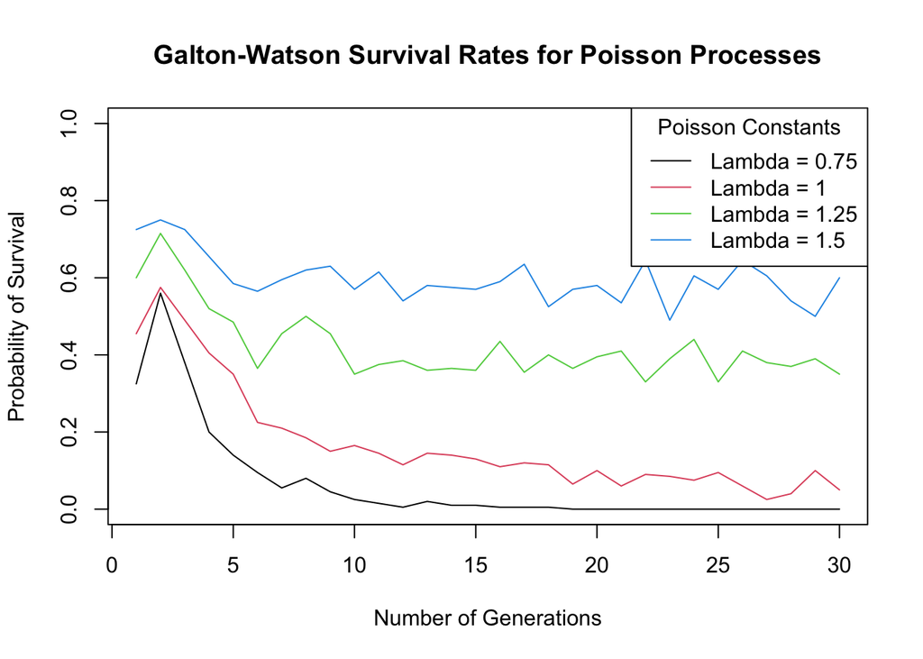

```r
simulate_survival <- function(num_generations, lambda) {
  total_individuals <- 1

  for (i in 2:num_generations) {
    offspring <- 0

    for (j in 1:total_individuals) {
      offspring <- offspring + rpois(1, lambda)
    }
    if (offspring == 0) {
      return(0)
    }
    total_individuals <- offspring
  }
  return(1)
}

poisson_constants <- c(0.75, 1.0, 1.25, 1.5)
num_simulations <- 200
num_generations <- 30
survival_probabilities <- matrix(NA, nrow = num_generations, ncol = length(poisson_constants))

for (i in 1:length(poisson_constants)) {
  for (gen in 1:num_generations) {
    survival_results <- replicate(num_simulations, simulate_survival(gen, poisson_constants[i]))
    survival_probabilities[gen, i] <- mean(survival_results)
  }
}

plot(1:num_generations, survival_probabilities[, 1], type = "l", col = 1,
                   ylim = c(0, 1), xlab = "Number of Generations",
                   ylab = "Probability of Survival",
                   main = "Galton-Watson Survival Rates for Poisson Processes")

for (i in 2:length(poisson_constants)) {
  lines(1:num_generations, survival_probabilities[, i], col = i)
}

legend("topright", legend = paste("Lambda =", poisson_constants),
       col = 1:length(poisson_constants), lty = 1, title = "Poisson Constants")
```

## Closing remarks

This introduction showed how to simulate a simple branching process in R and provided some key definitions and theoretical results of branching processes. However, these calculations and theory are only useful when we know the offspring distribution, $\{p_k\}$, which is rarely the case.

The next vignettes focus on inference for the offspring distribution given the growth data of a population. From this estimated offspring distribution, we can use the formulas and computations in this vignette (such as $\phi(s) = s$) to estimate the probability that the population will eventually go extinct.

Similar theorems, through argued for differently, are presented in Lalley’s [lecture notes](https://galton.uchicago.edu/~lalley/Courses/312/Branching.pdf) on stochastic processes.